# Homework #3: Penalized Regression

Your Name Here

Tue Feb 22 | 10:30 am

**SYS 4582/6018 | Spring 2022 | University of Virginia**

# Required R packages and Directories

```r
data.dir = 'https://mdporter.github.io/SYS6018/data' # data directory
library(mlbench)
library(glmnet)
library(R6018)     # functions for SYS-6018
library(tidyverse) # functions for data manipulation
```

# Problem 1: Optimal Tuning Parameters

In cross-validation, we discussed choosing the tuning parameter values that minimized the cross-validation error. Another approach, called the “one-standard error” rule [ISL pg 214, ESL pg 61], uses the values corresponding to the least complex model whose cv error is within one standard error of the best model. The goal of this assignment is to compare these two rules.

Use simulated data from `mlbench.friedman1(n, sd=2)` in the `mlbench` R package to fit *lasso models*. The tuning parameter $\lambda$ (corresponding to the penalty on the coefficient magnitude) is the one we will focus one. Generate training data, use k-fold cross-validation to get $\lambda_{\rm min}$ and $\lambda_{\rm 1SE}$, generate test data, make predictions for the test data, and compare performance of the two rules under a squared error loss using a hypothesis test.

Choose reasonable values for:

- Number of cv folds ($K$)
  - Note: you are free to use repeated CV, repeated hold-outs, or bootstrapping instead of plain cross-validation; just be sure to describe what do did so it will be easier to follow.
- Number of training and test observations
- Number of simulations
- If everyone uses different values, we will be able to see how the results change over the different settings.
- Don’t forget to make your results reproducible (e.g., set seed)

This pseudo code will get you started:

```yaml
library(mlbench)
library(glmnet)

#-- Settings
n.train =        # number of training obs
n.test =         # number of test obs
K =              # number of CV folds
alpha =          # glmnet tuning alpha (1 = lasso, 0 = ridge)
M =              # number of simulations

#-- Data Generating Function
getData <- function(n) mlbench.friedman1(n, sd=2)

#-- Simulations
# Set Seed Here

for(m in 1:M) {

# 1. Generate Training Data
# 2. Build Training Models using cross-validation, e.g., cv.glmnet()
# 3. get lambda that minimizes cv error and 1 SE rule
# 4. Generate Test Data
# 5. Predict y values for test data (for each model: min, 1SE)
# 6. Evaluate predictions

}

#-- Compare
# compare performance of the approaches / Statistical Test
```

## a. Code for the simulation and performance results

```r
#-- Settings
n.train = 500       # number of training obs
n.test = 50    # number of test obs
K = 10             # number of CV folds
alpha = 1         # glmnet tuning alpha (1 = lasso, 0 = ridge)
M = 100           # number of simulations

set.seed(100)
getData <- function(n) mlbench.friedman1(n, sd=2)

mse_1se_list = numeric()
mse_min_list = numeric()
for(m in 1:M) {

# 1. Generate Training Data
  ml_train_data = getData(n.train)
  ml_test_data = getData(n.test)
  X.train = ml_train_data$x
  Y.train = ml_train_data$y

  X.test = ml_test_data$x
  Y.test = ml_test_data$y
# 2. Build Training Models using cross-validation, e.g., cv.glmnet()
  lasso_cv = cv.glmnet(X.train, Y.train, alpha= alpha, nfolds = K)
  #plot(lasso_cv)
# 3. get lambda that minimizes cv error and 1 SE rule
  lambda_min = lasso_cv$lambda.min # best lambda
  lambda_1se = lasso_cv$lambda.1se # best lambda within one se of optimal
# 4. Generate Test Data
  #Above part done it

# 5. Predict y values for test data (for each model: min, 1SE)
  #coefficents = coef(lasso_cv, s = "lambda.min") # using lambda.min

  yhat = predict(lasso_cv, X.test, s = 'lambda.min', type = "response")


  yhat2 = predict(lasso_cv, X.test, s = 'lambda.1se', type = "response")

# 6. Evaluate predictions
  mse_min = mean((Y.test - yhat)^2)
  mse_min_list <- append(mse_min_list, mse_min)
  mse_1se = mean((Y.test - yhat2)^2)
  mse_1se_list <- append(mse_1se_list, mse_1se)

}

#-- Compare
# compare performance of the approaches / Statistical Test
t.test(mse_min_list, mse_1se_list)
```

```
#>
#>  Welch Two Sample t-test
#>
#> data:  mse_min_list and mse_1se_list
#> t = -1.9, df = 198, p-value = 0.06
#> alternative hypothesis: true difference in means is not equal to 0
#> 95 percent confidence interval:
#>  -1.21700  0.01562
#> sample estimates:
#> mean of x mean of y
#>     9.879    10.479
```

# Problem 2 Prediction Contest: Real Estate Pricing

This problem uses the [realestate-train](https://mdporter.github.io/SYS6018/data/realestate-train.csv) and [realestate-test](https://mdporter.github.io/SYS6018/data/realestate-test.csv) (click on links for data).

The goal of this contest is to predict sale price (in thousands) (`price` column) using an *elastic net* model. Evaluation of the test data will be based on the root mean squared error ${\rm RMSE}= \sqrt{\frac{1}{m}\sum_i (y_i - \hat{y}_i)^2}$ for the $m$ test set observations.

## a. Load the data and create necessary data structures for running *elastic net*.

- You are free to use any data transformation or feature engineering
- Note: there are some categorical predictors so at the least you will have to convert those to something numeric (e.g., one-hot or dummy coding).

```r
library(caret)
realest_train = read.csv('realestate-train.csv')
realest_test = read.csv('realestate-test.csv')

realest_train$CentralAir = factor(realest_train$CentralAir,
                           levels = c('N', 'Y'),
                           labels = c(0, 1))
realest_test$CentralAir = factor(realest_test$CentralAir,
                           levels = c('N', 'Y'),
                           labels = c(0, 1))

dummy <- dummyVars(" ~ .", data=realest_train)
dummy2 <- dummyVars(" ~ .", data=realest_test)
realest_train <- data.frame(predict(dummy, newdata=realest_train))
realest_test <- data.frame(predict(dummy2, newdata=realest_test))


#as.factor(realest_train$CentralAir)
```

## b. Use an *elastic net* model to predict the `price` of the test data.

- You are free to use any data transformation or feature engineering
- You are free to use any tuning parameters
- Report the $\alpha$ and $\lambda$ parameters you used to make your final predictions.
- Describe how you choose those tuning parameters

```r
#-- Get model matrices (returns a list of `x` and `xtest`)
X = glmnet::makeX(
train = realest_train %>% select(-price),
test = realest_test
)
X.train = X$x
Y.train = realest_train %>% pull(price)
X.test = X$xtest

#glmnet = glmnet(X.train, Y.train, alpha = 0.5)
#broom::tidy(glmnet) # predictions

glmnet_cv = cv.glmnet(X.train, Y.train, alpha=0,
nfolds = 10) # 10-fold cross-validation
min_glmnet_cv = mean(glmnet_cv$cvm)
best_alpha = 0
best_lambda = 0
for(n in 1:99){
  temp_glmnet_cv = cv.glmnet(X.train, Y.train, alpha=n/100,
nfolds = 10) # 10-fold cross-validation
  if(mean(temp_glmnet_cv$cvm) < min_glmnet_cv){
    best_alpha = n/100
    best_lambda = temp_glmnet_cv$lambda.min
  }
}
print("Best alpha value is :")
```

```
#> [1] "Best alpha value is :"
```

```r
print(best_alpha)
```

```
#> [1] 0.99
```

```r
#best_glmnet_cv = cv.glmnet(X.train, Y.train, alpha=best_alpha,
#nfolds = 10)
#lmin = best_glmnet_cv$lambda.min
#l1se = best_glmnet_cv$lambda.1se
print("The lambda for it is:")
```

```
#> [1] "The lambda for it is:"
```

```r
print(best_lambda)
```

```
#> [1] 0.626
```

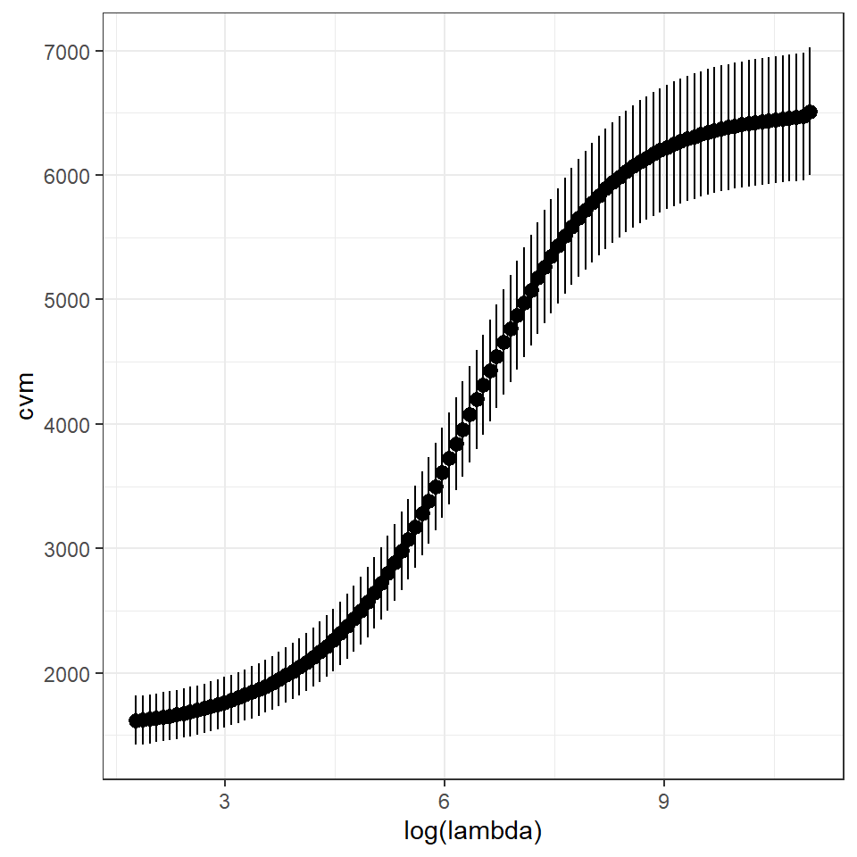

```r
with(glmnet_cv, tibble(lambda, cvm, cvsd, cvup, cvlo)) %>%
ggplot(aes(log(lambda), cvm)) +
geom_pointrange(aes(ymin=cvlo, ymax=cvup))
```

## c. Submit a .csv file (ensure comma separated format) named `lastname_firstname.csv` that includes your predictions in a column named *yhat*. We will use automated evaluation, so the format must be exact.

- You will receive credit for a proper submission; the top five scores will receive 2 bonus points.

```r
yhat2 = predict(best_glmnet_cv, X.test, s = 'lambda.min')
```

[output not shown]

```r
colnames(yhat2) = c("yhat")
write.csv(yhat2,"Tang_Jie.csv")
```

```r
#Using result from 2b, alpha and lambda. Make a 20-fold cv. Using RMSE insteaed.
glmnet_cv_2 = cv.glmnet(X.train, Y.train, alpha=0,
nfolds = 20) # 10-fold cross-validation
MIN_RMSE = sqrt(mean(glmnet_cv$cvm))
best_alpha_2 = 0
for(n in 1:99){
  temp_glmnet_cv = cv.glmnet(X.train, Y.train, alpha=n/100,
nfolds = 20) # 10-fold cross-validation
  if(sqrt(mean(temp_glmnet_cv$cvm)) < MIN_RMSE){
    best_alpha_2 = n/100
    best_lambda_2 = temp_glmnet_cv$lambda.min
  }
}

print(best_alpha_2)
```

```
#> [1] 0.99
```

```r
print(best_lambda_2)
```

```
#> [1] 0.626
```